# The spatial distribution and competition of Elk and Bison

Jieyi Zhu

12-5-2017

## Introduction

As we know that many problems in ecology involve modeling species interaction. The interspecies interaction and species spatial distribution provide fundamental information for understanding species coexistence in communities (Barraclough 2015). Therefore, there are a lot of ecological research focused on the outcome of the interactions of biological and ecological processes by analyzing spatial distribution patterns and associations.  
The Elk & Bison prairie is in the Land Between the Lakes National Recreation Area in Kentucky. In the mid-1970s, it just had a small patches of native prairie grasses inside. With the help of Biologists, the prairie grasses flourished after a period of years. Biologists then added elk, bison, and additional warm-season grasses to make up the original prairie. Therefore, only elk and bison are the two major ungulate species in the prairie.  
Elk and bison have similar food preference, Elk herd 80% grasses, 17% browse and 3% forbs, and bison herd 99% grasses and <1% others (Houston 1982). Since they herd grasses most of the time, the potential interspecific competition for food resources is a key consideration. This competition not only affect the species separation, but also affect the population size of each specie (Jung 2015). There is little report about the interspecies interaction of elk and bison in this prairie. It is hard to document and it is difficult to see if competition is driving species separation and age distribution. In this project, individual based model and spatial model were used to simulate the growth of population size, age distribution and spatial separation of each specie. Moreover, a Lotka Volterra model was used to simulate the competition, the result of population size was compared to the individual based model’s.

#### Purpose

The purpose of this project is to see if elk and bison could co-exist in the long run. The model that established in this project will show the population size, age distribution and spatial diffusion of each species. By comparing the trend of the population size, we could know if they are co-exist or not in the future. The model could be used to simulate the interspecies interaction in different situation by changing parameters.

#### Entities, state variables, and scales

- *Entities*: There are two species: bison (A) and elk (B).
- *Spatial and temporal scales*: One step represents 1 year and simulations were run for 10 years. Elk & Bison Prairie is a 700-acres enclosure [Elk & Bison Prairie Fact Sheet (2017)](https://landbetweenthelakes.us/wp-content/uploads/2013/11/17_ElkBisonFactSheet_WEB.pdf), and in this model 200-acres was used because it just has 10 steps. It would be enough to capture the information. Therefore, the model landscape comprised 1000 x 1000 = 1,000,000 square meters.
- *State Variables*: the co-ordinate `X` and `Y` show the location of bison or elk. `Age` add 1 in each step. The step also updated if the species survive or not.

#### Process overview and scheduling

To make the model easier to simulate, there are several assumptions. There are no human influence, no extreme weather, because a huge decrease or increase temperature would affect the birth rate and death rate.Both elk and bison only eats grasses and they don’t get their nutrients from anywhere. Both species have unlimited source of grasses and have limitless appetite. Both species have same constant birth rate and death rate.  
Both species will be reproduced. Reproduction and mortality will be stochastic functions, with reproductive rate depending on the total number of population and the landscape arena size. The state variables `X`, `Y`, `age` are immediately assigned a new value as soon as that value is calculated in update step.  
The population size is stored until all agents have executed the process.

#### Design concepts

- *Basic principles* : The model use IBM and spatial model.
- *Interaction*:There is direct interactions between bison and elk.
- *Stochasticity* : Reproduction and mortality will be stochastic functions.

## Methods

- Individual based model
- Lotka Volterra model

#### 1. Individual based model

Individual based model are simulations based on the global consequences of local interactions of members of a population. In this project, the model will contain a diffusion-reaction model. It also need to consider the Local density-dependence of each specie and the species interaction.

##### 1.1 Diffusion with population growth

Diffusion-reaction model
$$\frac{\partial Q}{\partial t} = D\nabla^2Q + f(Q)$$
where $\nabla^2=\left(\frac{\partial^2}{\partial x^2} + \frac{\partial^2}{\partial y^2}\right)$ in two spatial dimensions.$f(Q)$ is the local growth equation.$D$ is the diffusion coefficient.

##### 1.2 Local density-dependence

Calculate the distance from each individual to every other individual.
$$N_i = \sum_j e ^ {-\theta d_{ij} ^ 2}$$
$d_{ij}$ is the distance between individual $i$ and individual $j$. $\theta$ sets the range of influence of one individual on another.

##### 1.3 Species interactions

Species interaction with species effect parameters which indicate the strenth of compettion.
$$\lambda_1 = e^{r_1 \left( 1 - \frac{N_1+ \alpha_{12}N_2}{K} \right)}$$
$\lambda_1$ is the average number of offspring per mother of species 1. $r_1$ is the log-maximum growth rate for species 1. $N_1$ and $N_2$ are the local density of species 1 and 2. $K$ is the local combined density at which a mother is expect to produce one offspring. $\alpha_{12}$ is the effect of specie 2 on specie 1

#### 2. Lotka Volterra model

The equation used in this model is competitive Lotka Volterra equations which are a simple model for simulate the popluation dynamics of species competing for some common resource.
$$\frac{d N_1}{d t} = r_1 N_1(1 - N_1\alpha_{11} - N_2\alpha_{12}),
\frac{d N_2}{d t} = r_2 N_2(1 - N_1\alpha_{22} - N_2\alpha_{21})$$
$N_1$ and $N_1$ are the population size of species 1 and species 2 respectively. $r_1$ and $r_2$ are the instrinsic growth rate of species 1 and species 2 respectively. $\alpha_{11}$ and $\alpha_{22}$ are intraspecies interaction within species 1 and species 2 respectively. $\alpha_{12}$ is the effect from species 2 on species 1. $\alpha_{21}$ is the effect from species 1 on species 2

### Required libraries

- `tidyverse` package: a set of packages that includes ggplot2 package that could be used for plots
- `parallelDist`package: Parallel Distance Matrix Computation using Multiple Threads
- `deSolve` package: contains ode function which are ordinary differential equations used to simulated the population in time t.
- `lintr` package: is used to checking the code format.

```r
pacman::p_load(tidyverse)
pacman::p_load(deSolve) # nolint
pacman::p_load(parallelDist)
pacman::p_load(lintr)
```

### Model implementation

- The `intialize_model` function is used to setup the parameters at the first begining. The parameters are *llowed to change when intial the model.
- The `update_model` function is used to update the state in each step
- The `get_state` function will obtain the state information in each step after using `update_model` function.

```r
initialize_model <- function(n = 10, # initial pop size
                            D = 1, # diffusion coefficient
                            bound = 1000, # area size
                            sigma = 1, # initial spread
                            r0 = log(2), # max growth rate
                            K = 10, # local carrying capacity species 1
                            delta = 0.1, # death rate
                            alpha_1_2 = 2, # effect of 2 on 1
                            alpha_2_1 = 1, # effect of 1 on 2
                            theta = 0.01, # scale zone of influence
                            max_time = 30, # abort after this many seconds
                            max_individuals = 1e6,
                            sp = sample(rep(c("A", "B"), length = n)),
                            # random assignment to species
                            sp_age = data.frame(sp, age = rep(0, n))
                            ){
       list(x = rnorm(n, bound / 2, sigma), # random initial location
       y = rnorm(n, bound / 2, sigma), # random initial location
       sp = sp,
       D = D, bound = bound, t = 0,
       r0 = r0, K = K, delta = delta,
       alpha_1_2 = alpha_1_2, alpha_2_1 = alpha_2_1, # competition coefficients
       theta = theta, stamp = Sys.time(),
       max_individuals = max_individuals,
       max_time = max_time,
       sp_age = sp_age)
}

max_individuals <- NULL
stamp <- NULL
max_time <- NULL
theta <- NULL
x <- NULL
y <- NULL
sp <- NULL
r0 <- NULL
K <- NULL
delta <- NULL

update_model <- function(model){
  with(model, {
    sp_age$age <- sp_age$age + 1
    N <- length(x)
    if (N > max_individuals) stop( "Too many individuals")
    if (Sys.time() - stamp > max_time) stop("Run time exceeded")
    w <- exp(-theta * as.matrix(parDist(cbind(x, y))) ^ 2) # distance weights
    N1 <- rowSums(w[, sp == "A"])
    N2 <- rowSums(w[, sp == "B"]) # sum up by species
    Ni <- numeric(N) # reserve space
    Ni[sp == "A"] <- N1[sp == "A"] +
                     alpha_1_2 * N2[sp == "A"] # Ni for species 1
    Ni[sp == "B"] <- N2[sp == "B"] +
                     alpha_2_1 * N1[sp == "B"] # Ni for species 2
    n_offspring <- rpois(N, exp(r0 * (1 - Ni / K))) # one number per parent
    offspring_x <- rep(x, n_offspring) # offspring at same location as parent
    offspring_y <- rep(y, n_offspring) # offspring at same location as parent
    offspring_sp <- rep(sp, n_offspring) # offspring species same as parent
    i_survive <- rbinom(N, 1, delta) == 0 # survive if == 0
    x <- append(x[i_survive], offspring_x)
    y <- append(y[i_survive], offspring_y)
    sp <- append(sp[i_survive], offspring_sp)
    offspring_age <- data.frame(sp = offspring_sp,
                                age = rep(0, length(offspring_sp)))
    sp_age <- rbind(sp_age[i_survive, ], offspring_age)
    return(list(x = (x + rnorm(length(x), sd = 2 * D)) %% bound,
                y = (y + rnorm(length(y), sd = 2 * D)) %% bound,
                alpha_1_2 = alpha_1_2, alpha_2_1 = alpha_2_1,
                sp = sp, D = D, bound = bound, t = t + 1,
                r0 = r0, K = K, delta = delta,
                theta = theta, stamp = stamp,
                max_individuals = max_individuals,
                max_time = max_time,
                sp_age = sp_age))
  })
}

get_state <- function(model){
  with(model, {
    return(data_frame(x = x, y = y, sp = sp, t = t))
    # output Ni so we can plot it
    })
}
```

## Results

### 1. IBM model simulation

```r
# model initialization
set.seed(12345)
mod <- initialize_model(D = 3, n = 10, sigma = 0.1, K = 5,
                       theta = 0.01, r0 = log(2), delta = 0.1,
                       max_time = 120, alpha_1_2 = 2, alpha_2_1 = 1,
                       bound = 1000)

# get the state of inital model
res <- get_state(mod)

t_max <- 10 # 10 steps for simulate 10 years
sp_type <- c("A", "B") # A is bison, B is elk

# Make data frame N for store the population size of each species
N <- data.frame(NA, dim = c(t_max, length(sp_type)))
# set the column names of N dataframe
colnames(N) <- sp_type
# store the age of each species at t=0
N[1, ] <- summary(mod$sp_age$sp)

# update model in 10 times.
for (t in 1:t_max + 1){
  mod <- update_model(mod)
  res <- rbind(res, res1 = get_state(mod))
  N[t, ] <- summary(mod$sp_age$sp)
  sp_age <- mod$sp_age
}

# combine the population size and time interval
pop_data <- data.frame(t = 1:(t_max + 1), N)
# Get the total population size in each time interval
pop_data$total <- pop_data$A + pop_data$B
```

1.1 The figure 1 below shows that the total population have a steep increase 10 steps. Elk always has a larger population size than Bison when the time increase in each step.

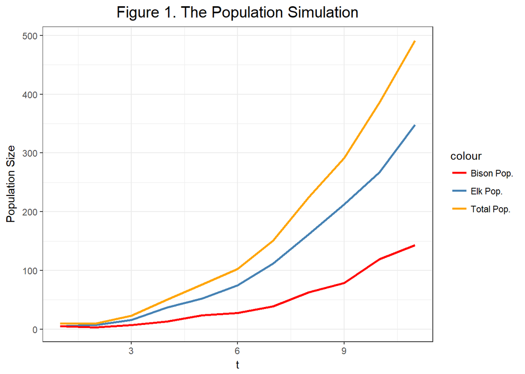

```r
# The population size plot
cols <- c("Elk Pop." = "steelblue",
          "Bison Pop." = "red",
          "Total Pop." = "orange")
p_pop <- ggplot(pop_data, aes(x = t))
p_pop <- p_pop +
         geom_line(aes(y = B, color = "Elk Pop."), lwd = 1 ) +
        geom_line(aes(y = A, color = "Bison Pop."), lwd = 1) +
        geom_line(aes(y = total, color = "Total Pop."), lwd = 1) +
        ylab("Population Size")

p_pop  <- p_pop + scale_colour_manual(values = cols) +
          theme_bw() +
          ggtitle("Figure 1. The Population Simulation") +
          theme(plot.title = element_text(hjust = 0.5, size = 15))
p_pop
```

1.2 The figure 2A and 2B shows the Age distributrion of Bison and Elk respectively. The age distribution plots show that the distribution are not Normal. In figure 2A, the 1-year old has the largest population size. The trend shows it decrease after 10 years, although there are some up and down between 2-years old and 10-years old. In figure 2B When the time increase, the number of older age decrease. . Most of agents are the new born, one-year old and two years old. These reslut suggests that both bison and elk would co-exist in the coming 10 years.

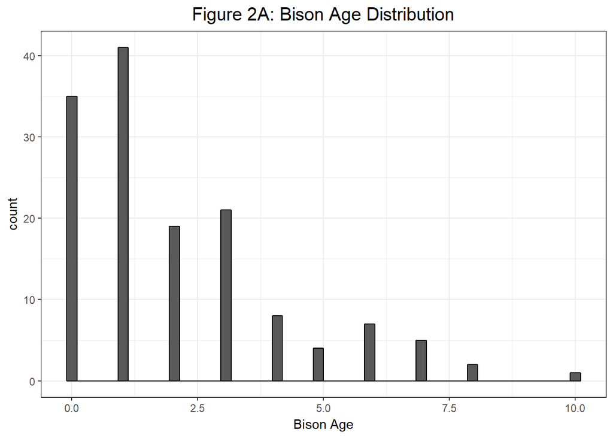

```r
# Age distribution

p_age <- ggplot(sp_age[sp_age$sp == "A", ], aes(x = age)) +
         geom_histogram(color = "black", bins = 50)
p_age_Bison <- p_age +
         ggtitle("Figure 2A: Bison Age Distribution") +
         theme_bw() +
         theme(plot.title = element_text(hjust = 0.5, size = 15)) +
         labs(x = "Bison Age")

p_age_Bison
```

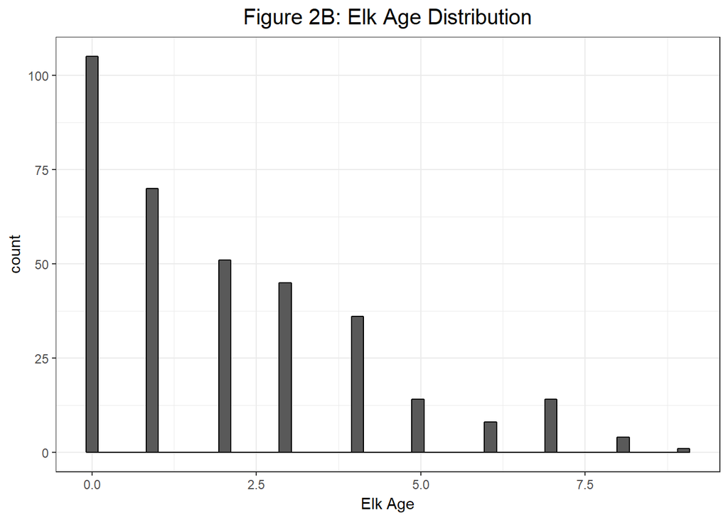

```r
p_age <- ggplot(sp_age[sp_age$sp == "B", ], aes(x = age)) +
         geom_histogram(color = "black", bins = 50)
p_age_elk <- p_age +
         ggtitle("Figure 2B: Elk Age Distribution") +
         theme_bw() +
         theme(plot.title = element_text(hjust = 0.5, size = 15)) +
         labs(x = "Elk Age")

p_age_elk
```

1.3 The figure 3 below shows how the bison(A) and elk(B) diffuse from time 0 to time 10(years). In the first year, there are only 5 for each species. The are very close in the center. When time goes up, each species have larger population size than previous step and diffuse more to other aera. In each step, they always have a cluster for each species, but elk always have larger population size than bison.

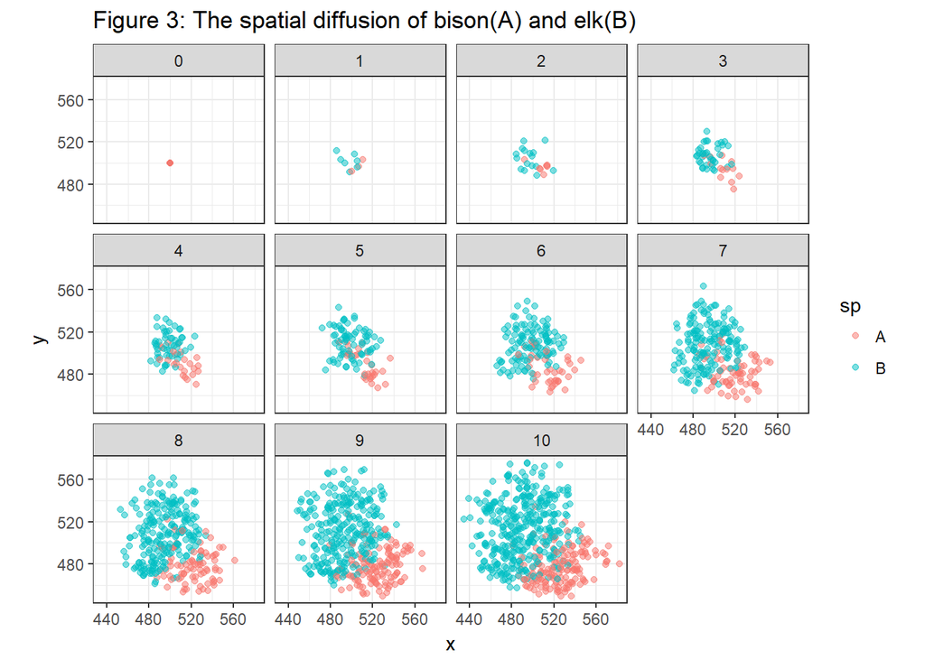

```r
# The spatial diffusion.
ggplot(res) +
  geom_point(aes(x = x, y = y, color = sp), alpha = 0.5) +
  facet_wrap(~t) +
  coord_fixed() +
  theme_bw() +
  ggtitle("Figure 3: The spatial diffusion of bison(A) and elk(B)")
```

### 2. LotKa Volterra model simulation

The model was also initialed with the same population size 5 for both species. The inital time point is at time zero The total carrying capacity for bison $\frac{1}{a11}$ and elk $\frac{1}{a22}$ are 500, both species have same growth rate r0 = 0.9. Tthe effect from species 2 on species 1 $a12$ is 0.004, but the effect from species 1 on species 2 $a21$ is 0.002. The max time is 10 which indicate there 10 steps in the model.

```r
lvcomp2 <- function (t, n, parms){
  with(as.list(parms), {
    dn1dt <- r1 * n[1] * (1 - a11 * n[1] - a12 * n[2])
    dn2dt <- r2 * n[2] * (1 - a22 * n[2] - a21 * n[1])
    list(c(dn1dt, dn2dt))
    })
}

r1 <- NULL
r2 <- NULL
a11 <- NULL
a12 <- NULL
a22 <- NULL
a21 <- NULL

parms <- c(r1 = 0.9, r2 = 0.9, a11 = 0.002,
           a21 = 0.002, a22 = 0.002, a12 = 0.004)
initialN <- c(5, 5)
out <- ode(y = initialN, times = 1:10, func = lvcomp2, parms = parms)
```

2.1 The Figure 4 below shows the population competition of Bison and Elk. The size go up at the same rate before the step 4, however, the number of elk increase more than bison in the rest of steps. The size of Bison suddent decrease from the step 6 to step 10. However, elk still increase to step 10.

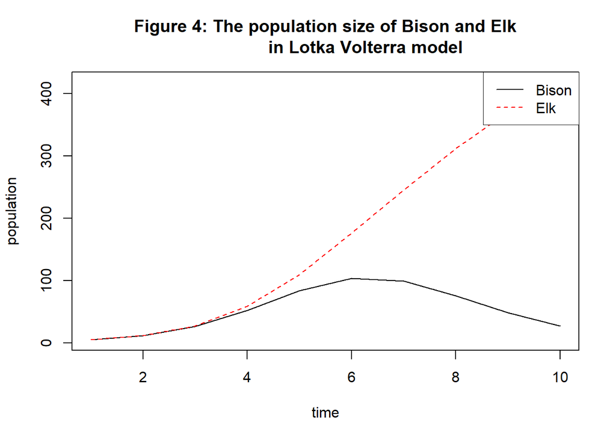

```r
matplot(out[, 1], out[, -1], type = "l", xlab = "time", ylab = "population",
        main = "Figure 4: The population size of Bison and Elk
                in Lotka Volterra model")
legend("topright", c("Bison", "Elk"), lty = c(1, 2), col = c(1, 2), box.lwd = 0)
```

2.2 The Figure 5 below shows the relationship of the population size of bison and elk. N1 and N2 both grow from the first begining to step 6, although N2 always bigger than N1 in each step. It suggest the effect of elk on bison is not severe . However after step 6, with higher population of elk, less population of bison. It suggest bison is highly affected by elk.

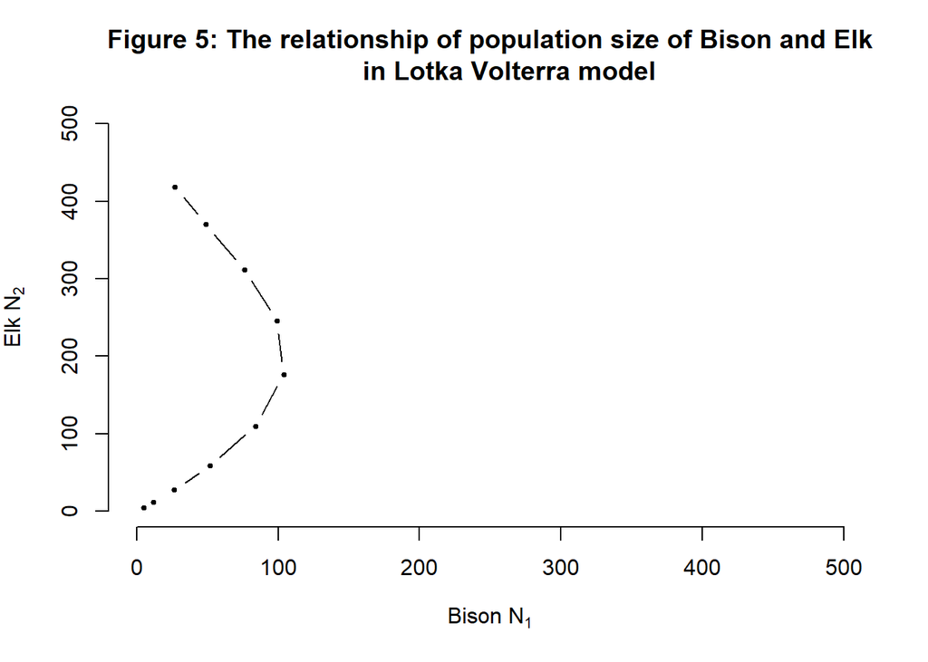

```r
plot(1, 1, type =  "n", ylim =  c(0, 500), xlim = c(0, 500), frame = F,
       ylab = expression("Elk N"[2]), xlab = expression("Bison N"[1]),
     main = "Figure 5: The relationship of population size of Bison and Elk
     in Lotka Volterra model")
points(out[, 2], out[, 3], type = "b", cex = 0.5, pch = 19)
```

## Discussion

### 1. The IBM Method

The IBM simulate only elk and bison competion. As expected, the model could simulate if elk and bison co-exist in the coming 10 year. The result did show they could co-exist in the near future. The trend of both species are going up, but didn’t show if they would reach the capacity, and if elk would out-compete bison after 10 year.

#### 1.1 Parameters

Due to lack of report and document about the Elk & Bison prairie, it is difficult to set up perfect parameters. For examples, the total population size of each species are not documented, the growth rate are not known. In this model, all parameters were fake. The model is just in early stage, we could change the parameter once we get the information after further research. It might also need more parameters, such as grasses growth rate and herd rate, to improve the model.

#### 1.2 Predators

There are not just elk and bison in the prairie, numerous other wildlife species also thrive there. It might be good to introdue the third ungulate species into the model which would give a more accurate result.

### 2 LotKa Volterra model simulation

The LotKa Volterra model also simulate only elk and bison competion. This model also could simulate if elk and bison co-exist in the coming 10 year. The result show they could co-exist in the near future. unlike IBM method, the trends of both species are not the same. Elk always has large growth in year by year, but bison has a slow growth until the sixth year, and drop year by year. It highly suggest that elk would out-compete bison after 10 year.

#### 2.2 Find the equilibria

Since the result suggest elk would out-compete bison after 10 year. It would be great to investigte how both the elk and bison could co-exist in the long run. It would be interesting to know what kind of factors that we could control to achieve this goal.

### 3. Conclusion

Overall, this project is just in early stage. Once we get more information from further research, the model could be modified and adpat to future use. This model would be helpful not only in the Elk and Bison prairie, but also might be applied to other system which have similar situation.

## References:

- Barraclough, T. G. How Do Species Interactions Affect Evolutionary Dynamics Across Whole Communities? Annu. Rev. Ecol. Evol. Syst. 46, 25-48 (2015).
- Jung, T. S., Stotyn, S. A. & Czetwertynski, S. M. Dietary overlap and potential competition in a dynamic ungulate community in Northwestern Canada. J. Wildl. Manage. 79, 1277-1285 (2015).
- Houston, D. B. The northern Yellowstone elk : ecology and management. (Macmillan, 1982).
- [Elk & Bison Prairie Fact Sheet (2017)](https://landbetweenthelakes.us/wp-content/uploads/2013/11/17_ElkBisonFactSheet_WEB.pdf).